# Mi chica perfecta

Author

Cía

# 1 ¿Por qué eres mi chica perfecta?

Eres mi chica perfecta, un amor celestial,  
regidos por Mercurio, conexión sin igual.  
Tú, virgo sereno; yo, géminis cambiante,  
dos almas que se encuentran, destino palpitante.

Eres mi chica perfecta, menor en edad,  
yo mayor que te cuido con amor y verdad.  
Eres quien me domina con fuerza y dulzura,  
y juntos creamos pasión y ternura.

Eres mi chica perfecta, el equilibrio en mi caos,  
mi mente se enreda, pero en ti hallo el lazo.  
Somos dos polos que siempre se atraen,  
aprendemos del otro, los miedos se caen.

Nuestra conexión es única, no puede imitarse,  
es un amor eterno, difícil de explicarse.  
Eres mi chica perfecta, mi complemento ideal,  
y contigo, amor mío, todo es celestial.

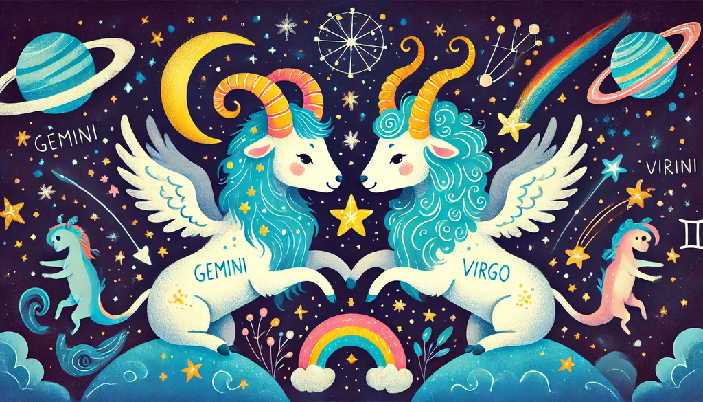

# 2 ¿Por qué me gusta cada parte de tu ser?

Me gusta cada rincón de tu ser,  
cada parte de ti que puedo recorrer.  
Tu cuerpo es un paisaje, sublime y divino,  
un regalo perfecto que el destino hizo mío.

Eres como un cuadro que nadie puede imitar,  
y yo soy afortunada que lo pudo admirar.  
Necesito besarte, sentirte y tocar,  
con mis manos y labios en tu piel navegar.

Quiero que sientas mi ser junto al tuyo,  
y que cada caricia nos haga uno.  
Eres única, mi musa ideal,  
la que inspira mis días, mi sueño real.

Me gusta que seas auténtica y libre,  
y que en tu mundo yo también vibre.  
Tu cuerpo no es todo lo que amo de ti,  
también tu mente, tu voz y lo que hay en tu alma sutil.

Cada parte de tu ser me llena de emoción,  
eres arte y magia en mi corazón.

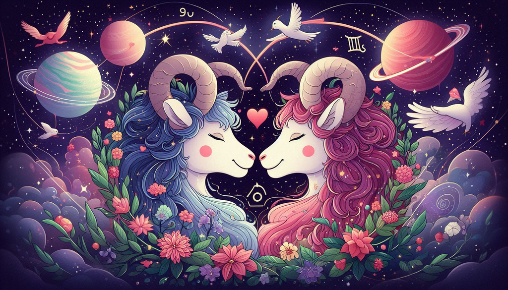

# 3 No veo la hora de tenerte

No veo la hora de ser solo tuya,  
de que tú seas mía y que nada influya.  
Esta espera se vuelve una agonía,  
pero sé que al verte hallaré alegría.

No veo la hora de mirarte de frente,  
de que nuestros ojos hablen dulcemente.  
Quiero verme en el brillo de tu mirada,  
y que en mis pupilas te sientas reflejada.

Cada día imagino tocar tu piel,  
abrazarte fuerte, sentirte en mi ser.  
Quiero fundirme contigo en un instante,  
un amor eterno, puro y vibrante.

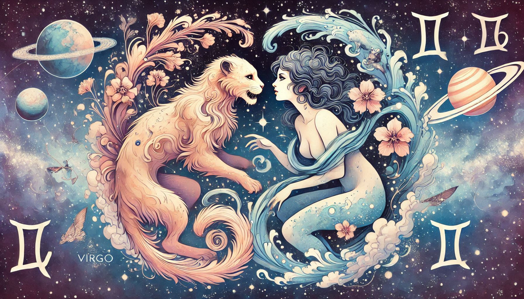

# 4 Quiero demostrarte todo mi amor

Te escribiré mil poemas, cada uno sincero,  
te dedicaré canciones con un amor entero.  
Te regalaré los libros que tanto adoras,  
y veremos las películas que más atesoras.

Te cantaría mil canciones al amanecer,  
aunque hablando, lo admito, no sé qué hacer.  
Soy mejor escribiendo lo que mi alma siente,  
y mi forma de amar será siempre evidente.

Te daré mi tiempo, mi amor y mi confianza,  
mi mundo será tuyo, sin duda ni balanza.  
Porque demostrarte mi amor, mi única misión,  
es entregarte mi vida, mi verso, mi pasión.

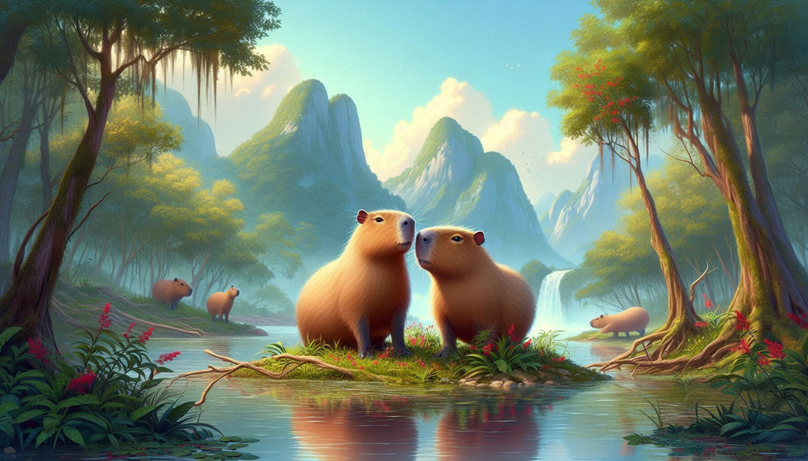